# Transferbericht ‘Ursache tödlicher Unfälle im Kanton Zürich’

# Datenquellen

## Unfalldaten

- https://opendata.swiss/de/dataset/polizeilich-registrierte-verkehrsunfalle-im-kanton-zurich
- https://opendata.swiss/de/dataset/polizeilich-registrierte-verkehrsunfalle-im-kanton-zurich/resource/1b2a47b7-ea16-4264-9bb6-d743cebdbd76

Die Verkehrsunfallstatistik des Kantons Zürich (VUSTA) enthält die Strassenverkehrsunfälle mit Personen- und Sachschäden, die durch die Kantonspolizei Zürich, die Dienstabteilung Verkehr der Stadt Zürich sowie die Stadtpolizei Winterthur registriert wurden. Sie wird einmal jährlich aktualisiert, jeweils gegen Ende des ersten Quartals des Folgejahres.

Zu jedem Strassenverkehrsunfall sind der Unfallort (geokodiert), das Jahr, der Monat, der Wochentag, die Unfallstunde, die Strassenart, der Unfalltyp (ab 1. Juli 2015 inklusive Bagatellunfälle zB. Parkschäden), die Unfallbeteiligung (‘Fussgänger’, ‘Velo (ohne E-Bikes)’, ‘Motorrad’) und die Unfallschwerekategorie verfügbar. Detaillierte Definitionen der Variabeln sind in der Ressource “Minimales Geodatenmodell Strassenverkehrsunfallorte (ASTRA)” dokumentiert.

Die Datei “KTZH_00000718_00001783.csv” wurde am 11.03.2022 heruntergeladen. Am 16.03.2022 wurde eine neue Version veröffentlicht, welche mit dem Script nicht kompatibel ist.

## Motorisierter Individualverkehr

- https://data.stadt-zuerich.ch/dataset/sid_dav_verkehrszaehlung_miv_od2031

Die hier verfügbaren Datensätze beinhalten die täglich aktualisierten Messwerte zum motorisierten Individualverkehr (MIV) in der Stadt Zürich, welche von den zahlreichen Zählstellen der Dienstabteilung Verkehr (DAV) gemessen wurden.

Die Aktualisierung beinhaltet jeweils die Daten von vorgestern (z.B. am 17.1.2021 werden die Daten bis und mit dem vollendeten 15.1.2021 geliefert). Bis spätestens 08:00 Uhr sind die neuesten Daten verfügbar.

Zu einer Messstelle gehören mehrere Zählstellen, welche wiederum Messungen mit sogenannten Detektoren vornehmen. In den vorliegenden Datensätzen sind die Messwerte pro Zählstelle enthalten. Für jede Zählstelle gibt es einen detaillierten PDF-Situationsplan in der Datei “Zaehlstellen_Detail.zip”, welcher u.a. die genaue Lage der Detektoren anzeigt.

## Fussgänger und Veloverkehr

- https://data.stadt-zuerich.ch/dataset/ted_taz_verkehrszaehlungen_werte_fussgaenger_velo

Die täglich aktalisierten **Zähldaten** werden vom Tiefbauamt der Stadt Zürich in eigener Regie erhoben. Die Zählstellen sind über das Stadtgebiet verteilt. Die Standorte sind auch über das [Geodatenportal](https://www.stadt-zuerich.ch/geodaten/download/Standorte_der_automatischen_Fuss__und_Velozaehlungen) erhältlich und können über das Attribut FK_ZAEHLER in Beziehung gesetzt werden. Die Erfassung des **Veloverkehrs** erfolgt mittels im Strassenbelag eingelassenen **Induktionsschlaufen**. Der **Fussverkehr** wird durch **passive Infrarotstrahlung** gezählt.

## Meteodaten

- https://data.stadt-zuerich.ch/dataset/ugz_meteodaten_stundenmittelwerte

Der Datensatz umfasst Stundenwerte ab 1992 bis zur letzten aktuellen Stunde aufgeteilt in Jahresdateien. Darin enthalten sind die Stationen Stampfenbachstrasse, Schimmelstrasse und Rosengartenstrasse. Gemessen wird der Luftdruck (p), die Niederschlagsdauer (RainDur), die Globalstrahlung (StrGlo), die Temperatur (T), die relative Luftfeuchtigkeit (Hr), die Windrichtung, die Vektor und Skalar Windgeschwindigkeit. Vor 2018 sind die Skalar Windgeschwindigkeiten aus den 30 Minuten Vektor Daten gerechnet worden. s Die Stundenwerte des laufenden Jahres werden jeweils 30 Minuten nach der vollen Stunde aktualisiert.

## Luftqualität

- https://data.stadt-zuerich.ch/dataset/ugz_luftschadstoffmessung_stundenwerte

Dieses Dataset umfasst Stundenmesswerte seit 1983 bis zur letzten aktuellen Stunde, aufgeteilt in Jahresdateien. Darin enthalten sind die Stundenmittelwerte des entsprechenden Jahres für die Stationen Stampfenbachstrasse, Schimmelstrasse, Rosengartenstrasse und Heubeeribüel. Gemessen wird Ozon (O3), Stickoxide (NOx), Stickstoffmonoxid (NO), Stickstoffdioxid (NO2), Feinstaub (PM10 und PM2.5), Kohlenmonoxid (CO) und Schwefeldioxid (SO2) wo jeweils in genügender Qualität vorhanden.

Die Stundenmittelwerte des laufenden Jahres werden jeweils 30 Minuten nach der vollen Stunde aktualisiert.

# Lineare Regression “Unfalldaten”

## Daten einlesen

```r
normalizeText <- function(x, length = 9) {
  res <- str_trim(x, side = 'both')
  res <- str_replace_all(res, ' ', '_')
  substr(res, 0, length)
}

# 'basedir' ist eine lokale Variable und verweist auf ein Verzeichnis in meiner Dropbox
accidentsFile <- paste0(basedir, 'KTZH_00000718_00001783.csv')
rawAccident <- read.csv(accidentsFile, header = TRUE, sep = ';', stringsAsFactors = TRUE)

accidentData <- rawAccident %>%
  select(AccidentUID, AccidentType_de, AccidentSeverityCategory_de, RoadType_de, MunicipalityCode, AccidentYear, AccidentMonth, AccidentWeekDay, AccidentHour) %>%
  mutate(AccidentType_de = normalizeText(AccidentType_de)) %>%
  mutate(AccidentSeverityCategory_de = normalizeText(AccidentSeverityCategory_de, 20)) %>%
  mutate(RoadType_de = normalizeText(RoadType_de)) %>%
  mutate(YearMonth = paste(AccidentYear, sprintf("%02.f", AccidentMonth), sep = '-'))

# Aus Gründen der Übersichtlichkeit wird die UID des Unfalls ausgeblendet
head(accidentData %>% select(-AccidentUID))
```

```
##   AccidentType_de AccidentSeverityCategory_de RoadType_de MunicipalityCode
## 1       Schleuder        Unfall_mit_Sachschad   Hauptstra              247
## 2       Schleuder        Unfall_mit_Sachschad   Nebenstra              261
## 3       Schleuder        Unfall_mit_Leichtver   Nebenstra              261
## 4       Schleuder        Unfall_mit_Sachschad    Autobahn              251
## 5       Schleuder        Unfall_mit_Sachschad      andere              261
## 6       Überquere        Unfall_mit_Leichtver   Nebenstra              261
##   AccidentYear AccidentMonth AccidentWeekDay AccidentHour YearMonth
## 1         2011             1           aw406            0   2011-01
## 2         2011             1           aw406            0   2011-01
## 3         2011             1           aw406            1   2011-01
## 4         2011             1           aw406            1   2011-01
## 5         2011             1           aw406            2   2011-01
## 6         2011             1           aw406            2   2011-01
```

```r
## Daten einlesen
```

## Unfall nach Typ

```r
accidentByType <- table(accidentData$YearMonth, accidentData$AccidentType) %>%
  as.data.frame() %>%
  pivot_wider(names_from = Var2, values_from = Freq, values_fill = 0) %>%
  rename(YearMonth = Var1)
tail(accidentByType, 12)
```

```
## # A tibble: 12 × 12
##    YearMonth Abbiegeun Andere Auffahrun Einbiegeu Frontalko Fussgänge Parkierun
##    <fct>         <int>  <int>     <int>     <int>     <int>     <int>     <int>
##  1 2020-01          43     18       219        73        13        38       203
##  2 2020-02          64     32       243        79         7        50       205
##  3 2020-03          38     10       147        67         6        23       177
##  4 2020-04          49     12       123        63         7        22       150
##  5 2020-05          70     14       220        86        13        29       189
##  6 2020-06          62     15       249       101        18        48       255
##  7 2020-07          56     22       270        90        23        35       247
##  8 2020-08          56     24       245        73        14        43       257
##  9 2020-09          61     30       261        91        17        43       227
## 10 2020-10          68     23       222       100        22        37       256
## 11 2020-11          69     18       201        70        13        35       204
## 12 2020-12          28     27       195        79        13        38       235
## # … with 4 more variables: Schleuder <int>, Tierunfal <int>, Überholun <int>,
## #   Überquere <int>
```

## Unfall nach Schwerekategorie

```r
accidentBySeverity <- table(accidentData$YearMonth, accidentData$AccidentSeverityCategory) %>%
  as.data.frame() %>%
  pivot_wider(names_from = Var2, values_from = Freq, values_fill = 0) %>%
  rename(YearMonth = Var1)
tail(accidentBySeverity, 12)
```

```
## # A tibble: 12 × 5
##    YearMonth Unfall_mit_Getö… Unfall_mit_Leic… Unfall_mit_Sach… Unfall_mit_Schw…
##    <fct>                <int>            <int>            <int>            <int>
##  1 2020-01                  0              174              946               26
##  2 2020-02                  4              189              977               31
##  3 2020-03                  5              138              740               31
##  4 2020-04                  4              226              629               39
##  5 2020-05                  0              296              910               76
##  6 2020-06                  5              304             1033               66
##  7 2020-07                  2              345             1056               68
##  8 2020-08                  0              299             1048               66
##  9 2020-09                  3              323             1044               71
## 10 2020-10                  2              223             1109               48
## 11 2020-11                  3              198              923               29
## 12 2020-12                  2              166             1009               25
```

## Unfall nach Strassentyp

```r
accidentByRoadType <- table(accidentData$YearMonth, accidentData$RoadType) %>%
  as.data.frame() %>%
  pivot_wider(names_from = Var2, values_from = Freq, values_fill = 0) %>%
  rename(YearMonth = Var1)
tail(accidentByRoadType, 12)
```

```
## # A tibble: 12 × 7
##    YearMonth Autobahn Autostras Hauptstra Nebenanla Nebenstra andere
##    <fct>        <int>     <int>     <int>     <int>     <int>  <int>
##  1 2020-01        173         8       276         2       585    102
##  2 2020-02        182        10       294         1       600    114
##  3 2020-03        121         2       219         0       479     93
##  4 2020-04         72         5       217         3       516     85
##  5 2020-05        132         6       343         2       690    109
##  6 2020-06        150         9       365         2       743    139
##  7 2020-07        185        12       364         4       782    124
##  8 2020-08        191        14       318         1       735    154
##  9 2020-09        197        14       341         4       776    109
## 10 2020-10        162         5       336         5       734    140
## 11 2020-11        148        14       271         2       618    100
## 12 2020-12        142         7       281         0       661    111
```

## Unfall nach Stunde

Wird in der Regressionsanalyse nicht weiter verwendet.

```r
accidentByHour <- table(accidentData$YearMonth, accidentData$AccidentHour) %>%
  as.data.frame() %>%
  pivot_wider(names_from = Var2, values_from = Freq, values_fill = 0) %>%
  rename(YearMonth = Var1)
tail(accidentByHour, 12)
```

```
## # A tibble: 12 × 25
##    YearMonth   `0`   `1`   `2`   `3`   `4`   `5`   `6`   `7`   `8`   `9`  `10`
##    <fct>     <int> <int> <int> <int> <int> <int> <int> <int> <int> <int> <int>
##  1 2020-01      24     8     8     6    12    20    33    90    63    54    55
##  2 2020-02      20    15    13    10     3    19    54    77    69    50    80
##  3 2020-03      19    10     5     6     4     5    32    45    64    52    61
##  4 2020-04      15     8     4     4    10     5    13    34    32    38    50
##  5 2020-05      18    11     6     7     9     9    34    48    55    57    73
##  6 2020-06      24    17     4     9     8    12    29    65    70    70    94
##  7 2020-07      20     9     7    14    14    20    45    53    57    78    78
##  8 2020-08      21    17    12    10    12    15    37    60    70    61    96
##  9 2020-09      25    11     9     9    11    20    35    73    76    66    81
## 10 2020-10      16    16    12     4     5    13    50    68    72    65    71
## 11 2020-11      20     8     0     7     5     3    55    51    67    58    64
## 12 2020-12      27    20    11    16     8    22    35    50    63    47    74
## # … with 13 more variables: `11` <int>, `12` <int>, `13` <int>, `14` <int>,
## #   `15` <int>, `16` <int>, `17` <int>, `18` <int>, `19` <int>, `20` <int>,
## #   `21` <int>, `22` <int>, `23` <int>
```

## Unfall nach Wochentag

```r
accidentByWeekDay <- table(accidentData$YearMonth, accidentData$AccidentWeekDay) %>%
  as.data.frame() %>%
  pivot_wider(names_from = Var2, values_from = Freq, values_fill = 0) %>%
  rename(YearMonth = Var1) %>%
  rename(Mo = aw401, Di = aw402, Mi = aw403, Do = aw404, Fr = aw405, Sa = aw406, So = aw407)
tail(accidentByWeekDay, 12)
```

```
## # A tibble: 12 × 8
##    YearMonth    Mo    Di    Mi    Do    Fr    Sa    So
##    <fct>     <int> <int> <int> <int> <int> <int> <int>
##  1 2020-01     170   158   202   202   180   131   103
##  2 2020-02     190   149   177   189   203   205    88
##  3 2020-03     177   141   137   118   141   104    96
##  4 2020-04     117   116   179   158   128   110    90
##  5 2020-05     172   172   195   193   225   189   136
##  6 2020-06     210   280   247   201   192   183    95
##  7 2020-07     193   213   249   256   244   194   122
##  8 2020-08     228   197   198   185   242   196   167
##  9 2020-09     177   252   266   213   229   193   111
## 10 2020-10     166   181   180   236   270   212   137
## 11 2020-11     192   160   188   145   206   152   110
## 12 2020-12     157   235   223   175   190   137    85
```

## Zusammenfassung

```r
accidentByMonth <- accidentData %>%
  group_by(YearMonth) %>%
  summarise(TotalAccidents = n())
tail(accidentByMonth, 12)
```

```
## # A tibble: 12 × 2
##    YearMonth TotalAccidents
##    <chr>              <int>
##  1 2020-01             1146
##  2 2020-02             1201
##  3 2020-03              914
##  4 2020-04              898
##  5 2020-05             1282
##  6 2020-06             1408
##  7 2020-07             1471
##  8 2020-08             1413
##  9 2020-09             1441
## 10 2020-10             1382
## 11 2020-11             1153
## 12 2020-12             1202
```

```r
NROW(accidentByMonth)
```

```
## [1] 120
```

```r
mean(accidentByMonth$TotalAccidents)
```

```
## [1] 1233.092
```

```r
sum(accidentByMonth$TotalAccidents)
```

```
## [1] 147971
```

```r
min(accidentByMonth$YearMonth)
```

```
## [1] "2011-01"
```

```r
max(accidentByMonth$YearMonth)
```

```
## [1] "2020-12"
```

## Alle Daten zusammenführen

```r
accidentFreq <- accidentByMonth %>%
  # full_join(accidentByHour, by = 'YearMonth') %>%
  full_join(accidentByWeekDay, by = 'YearMonth') %>%
  full_join(accidentByType, by = 'YearMonth') %>%
  full_join(accidentBySeverity, by = 'YearMonth') %>%
  full_join(accidentByRoadType, by = 'YearMonth')

# Sanity checks
head(accidentFreq)
```

```
## # A tibble: 6 × 30
##   YearMonth TotalAccidents    Mo    Di    Mi    Do    Fr    Sa    So Abbiegeun
##   <chr>              <int> <int> <int> <int> <int> <int> <int> <int>     <int>
## 1 2011-01             1018   141   112   125   244   160   129   107        41
## 2 2011-02              851   127   110   122   119   145   125   103        34
## 3 2011-03             1071   143   192   161   182   177   127    89        46
## 4 2011-04             1159   149   142   184   195   198   186   105        57
## 5 2011-05             1284   217   203   194   165   190   179   136        70
## 6 2011-06             1127   134   174   213   211   149   152    94        52
## # … with 20 more variables: Andere <int>, Auffahrun <int>, Einbiegeu <int>,
## #   Frontalko <int>, Fussgänge <int>, Parkierun <int>, Schleuder <int>,
## #   Tierunfal <int>, Überholun <int>, Überquere <int>,
## #   Unfall_mit_Getöteten <int>, Unfall_mit_Leichtver <int>,
## #   Unfall_mit_Sachschad <int>, Unfall_mit_Schwerver <int>, Autobahn <int>,
## #   Autostras <int>, Hauptstra <int>, Nebenanla <int>, Nebenstra <int>,
## #   andere <int>
```

```r
# Still 120 months?
NROW(accidentFreq) == 120
```

```
## [1] TRUE
```

## Regressionsanalyse

Hypothese / Untersuchungsgegenstand: Welches sind die Haupteinfluss-Faktoren für “Unfall_mit_Getöteten”?

Mittel: Step-wise Vorwärts- und Rückwärts-Selektion sowie Suche in “beiden Richtungen” mit dem Akaike‘s AIC-Kriterium und dem Schwarz Informationskriterium (BIC).

### Vorbereitungen

```r
# Entfernen nicht mehr benötigte Daten
accidents <- accidentFreq %>%
  select(-YearMonth, -TotalAccidents, -Unfall_mit_Sachschad, -Unfall_mit_Leichtver, -Unfall_mit_Schwerver)

# Interzeptmodell als Ausgangmodell
nullModel <- lm(Unfall_mit_Getöteten ~ 1, data = accidents)
fullModel <- lm(Unfall_mit_Getöteten ~ ., data = accidents)

N <- NROW(accidents)
```

### AIC-Kriterium

```r
forwardModelAIC <- step(nullModel,
                        direction = "forward",
                        scope = formula(fullModel), k = 2, trace = 0)

backwardModelAIC <- step(fullModel,
                         direction = "backward",
                         scope = formula(fullModel), k = 2, trace = 0)

bothModelAIC <- step(fullModel,
                     direction = "both",
                     data = accidents, k = 2, trace = 0)
```

**Interpretation**

Mit allen drei Verfahren kommen die gleichen Regressoren heraus mit gleichem AIC:

```r
paste(AIC(forwardModelAIC), AIC(backwardModelAIC), AIC(bothModelAIC), sep = ", ")
```

```
## [1] "448.006256423627, 448.006256423627, 448.006256423627"
```

```r
paste(attr(forwardModelAIC$terms, "term"), sep = ", ")
```

```
## [1] "Abbiegeun" "Fr"        "Fussgänge" "Tierunfal" "Sa"        "Autobahn"
## [7] "Frontalko" "So"
```

```r
paste(attr(backwardModelAIC$terms, "term"), sep = ", ")
```

```
## [1] "Fr"        "Sa"        "So"        "Abbiegeun" "Frontalko" "Fussgänge"
## [7] "Tierunfal" "Autobahn"
```

```r
paste(attr(bothModelAIC$terms, "term"), sep = ", ")
```

```
## [1] "Fr"        "Sa"        "So"        "Abbiegeun" "Frontalko" "Fussgänge"
## [7] "Tierunfal" "Autobahn"
```

```r
finalModelAIC <- lm(Unfall_mit_Getöteten ~
                      Fr +
                        Sa +
                        So +
                        Abbiegeun +
                        Frontalko +
                        Fussgänge +
                        Tierunfal +
                        Autobahn, data = accidents)
summary(finalModelAIC)
```

```
##
## Call:
## lm(formula = Unfall_mit_Getöteten ~ Fr + Sa + So + Abbiegeun +
##     Frontalko + Fussgänge + Tierunfal + Autobahn, data = accidents)
##
## Residuals:
##     Min      1Q  Median      3Q     Max
## -3.2681 -0.8868 -0.3055  0.9596  3.5694
##
## Coefficients:
##              Estimate Std. Error t value Pr(>|t|)
## (Intercept)  2.515703   1.054844   2.385 0.018779 *
## Fr          -0.015005   0.004392  -3.416 0.000888 ***
## Sa           0.011098   0.005643   1.967 0.051696 .
## So           0.009357   0.006847   1.367 0.174503
## Abbiegeun    0.035209   0.013508   2.607 0.010402 *
## Frontalko    0.057109   0.033439   1.708 0.090458 .
## Fussgänge    0.035559   0.015551   2.287 0.024112 *
## Tierunfal   -0.040967   0.021387  -1.916 0.057993 .
## Autobahn    -0.019077   0.007067  -2.700 0.008028 **
## ---
## Signif. codes:  0 '***' 0.001 '**' 0.01 '*' 0.05 '.' 0.1 ' ' 1
##
## Residual standard error: 1.497 on 111 degrees of freedom
## Multiple R-squared:  0.2517, Adjusted R-squared:  0.1977
## F-statistic: 4.666 on 8 and 111 DF,  p-value: 6.103e-05
```

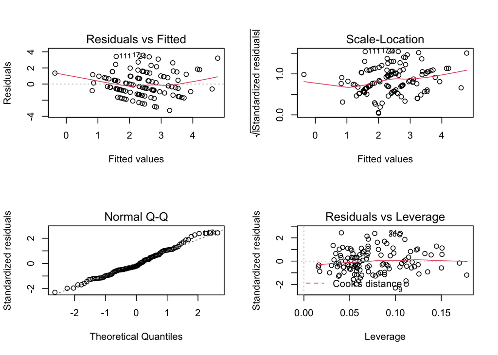

```r
layout(matrix(1:4, 2, 2))
plot(finalModelAIC)
```

```r
jarque.test(finalModelAIC$residuals)
```

```
##
##  Jarque-Bera Normality Test
##
## data:  finalModelAIC$residuals
## JB = 2.5572, p-value = 0.2784
## alternative hypothesis: greater
```

Die Residuen sind normalverteilt. Das Modell kann verwendet werden, siehe Analyse / Fazit.

### BIC-Kriterium

```r
forwardModelBIC <- step(nullModel,
                        direction = "forward",
                        scope = formula(fullModel), k = log(N), trace = 0)

backwardModelBIC <- step(fullModel,
                         direction = "backward",
                         scope = formula(fullModel), k = log(N), trace = 0)

bothModelBIC <- step(fullModel,
                     direction = "both",
                     data = accidents, k = log(N), trace = 0)
```

**Interpretation**

Mit allen drei Verfahren kommen die gleichen Regressoren heraus mit gleichem BIC:

```r
paste(BIC(forwardModelAIC), BIC(backwardModelAIC), BIC(bothModelAIC), sep = ", ")
```

```
## [1] "475.881173851447, 475.881173851447, 475.881173851447"
```

```r
paste(attr(forwardModelAIC$terms, "term"), sep = ", ")
```

```
## [1] "Abbiegeun" "Fr"        "Fussgänge" "Tierunfal" "Sa"        "Autobahn"
## [7] "Frontalko" "So"
```

```r
paste(attr(backwardModelAIC$terms, "term"), sep = ", ")
```

```
## [1] "Fr"        "Sa"        "So"        "Abbiegeun" "Frontalko" "Fussgänge"
## [7] "Tierunfal" "Autobahn"
```

```r
paste(attr(bothModelAIC$terms, "term"), sep = ", ")
```

```
## [1] "Fr"        "Sa"        "So"        "Abbiegeun" "Frontalko" "Fussgänge"
## [7] "Tierunfal" "Autobahn"
```

```r
finalModelBIC <- lm(Unfall_mit_Getöteten ~ Fr + Abbiegeun, data = accidents)
summary(finalModelBIC)
```

```
##
## Call:
## lm(formula = Unfall_mit_Getöteten ~ Fr + Abbiegeun, data = accidents)
##
## Residuals:
##     Min      1Q  Median      3Q     Max
## -3.3389 -0.9213 -0.1741  0.7858  4.7462
##
## Coefficients:
##              Estimate Std. Error t value Pr(>|t|)
## (Intercept)  2.002103   0.773064   2.590 0.010822 *
## Fr          -0.010850   0.003845  -2.822 0.005611 **
## Abbiegeun    0.049589   0.013203   3.756 0.000271 ***
## ---
## Signif. codes:  0 '***' 0.001 '**' 0.01 '*' 0.05 '.' 0.1 ' ' 1
##
## Residual standard error: 1.584 on 117 degrees of freedom
## Multiple R-squared:  0.1167, Adjusted R-squared:  0.1016
## F-statistic: 7.732 on 2 and 117 DF,  p-value: 0.0007015
```

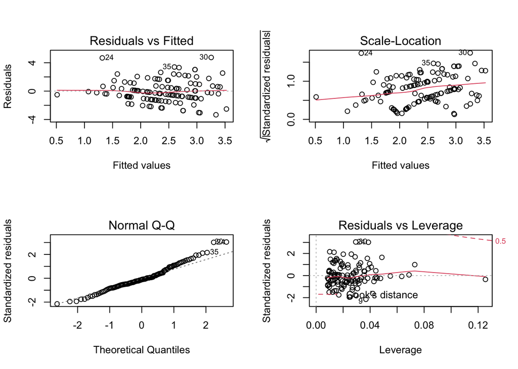

```r
layout(matrix(1:4, 2, 2))
plot(finalModelBIC)
```

```r
jarque.test(finalModelBIC$residuals)
```

```
##
##  Jarque-Bera Normality Test
##
## data:  finalModelBIC$residuals
## JB = 6.0343, p-value = 0.04894
## alternative hypothesis: greater
```

Die Residuen sind *nicht* normalverteilt. Das Model wird nicht weiter verfolgt.

## Analyse und Fazit

Uns ist bewusst, dass mit der vorliegenden Methode keine belastbaren, geschweige denn kausalen Zusammenhänge hergeleitet werden können. Zumal die Kennzahl R2 mit rund 0.25 darauf hinweist, dass das gewählte Regressionsmodell den Regressanden “Unfall_mit_Getöteten” nur ungenügend schwach erklären kann. Dennoch scheint sich zu bewahrheiten, dass die Wochentage Fr (***), Sa (.) und So (nicht signifikant), sowie Abbiegeunfälle (*), Frontalkollisionen (.), Unfälle mit Fussgängern (*) und auf Autobahnen (**) den stärksten Einfluss auf Unfälle mit Todesopfern haben. Dies entspricht unserer Ansicht nach durchaus den Erwartungen. Einzig der Einflussfaktor “Unfälle mit Tieren” (.) kommt etwas unerwartet.

*(In Klammern Signifikanzcodes: 0 ‘***’ 0.001 ‘**’ 0.01 ‘*’ 0.05 ‘.’ 0.1)*

Das Modell, welches mittels BIC gefunden wurde, wurde verworfen: Die Residuen sind nicht normalverteilt.

Alle Aussagen basieren auf einem Signifikanzniveau von 95%.

Interessant wäre vermutlich die Einflussfaktoren in den Gruppen einzeln zu analysieren, also Wochentage, Unfallart, Strassentyp und ggf. auch Stunde; als auch mit anderen Schwerekategorien zu untersuchen.